# Мини-проект по анализу корпуса текстов

Горчинская Арина, Турутин Никита, Астапенкова Арина

```r
# библиотеки
library(tidyverse)
library(dplyr)
library(ggplot2)
library(tidyr)
library(readr)
library(stringr)
library(forcats)
library(purrr)

library(tidytext)
library(stopwords)
#install.packages("udpipe")
library(udpipe)
library(topicmodels)
library(quanteda)
library(quanteda.textstats)
#install.packages("widyr")
library(widyr)
library(ggraph)
library(igraph)
```

## Описание данных

Данные содержат собранные в txt-файлы книгу “Мастер и Маргарита”, написанную Булгаковым. В данных 3 столбца:

- `chapter_number` - номер главы
- `chapter_name` - название главы
- `text` - текст.

```r
data <- read_csv('corpus_chapters.csv', show_col_types = FALSE) |>
  mutate(part = if_else(chapter_number <= 16, "первая", "вторая"), .before = 1) # добавление колонки с частью книги
head(data)
```

| part | chapter_number | chapter_name | text |
| --- | --- | --- | --- |
| первая | 1 | Никогда не разговаривайте с неизвестными | Однажды весною, в час небывало жаркого заката, в Москве, на Патриарших прудах, появились два гражданина. Первый из них, одетый в летнюю серенькую пару, был маленького роста, упитан, лыс, свою приличну… |
| первая | 2 | Понтий Пилат | В белом плаще с кровавым подбоем, шаркающей кавалерийской походкой, ранним утром четырнадцатого числа весеннего месяца нисана в крытую колоннаду между двумя крыльями дворца ирода великого вышел прокур… |
| первая | 3 | Седьмое доказательство | – Да, было около десяти часов утра, досточтимый Иван Николаевич, – сказал профессор.\nПоэт провел рукою по лицу, как человек, только что очнувшийся, и увидел, что на Патриарших вечер.\nВода в пруде по… |
| первая | 4 | Погоня | Утихли истерические женские крики, отсверлили свистки милиции, две санитарные машины увезли: одна – обезглавленное тело и отрезанную голову в морг, другая – раненную осколками стекла красавицу вожатую… |
| первая | 5 | Было дело в Грибоедове | Старинный двухэтажный дом кремового цвета помещался на бульварном кольце в глубине чахлого сада, отделенного от тротуара кольца резною чугунною решеткой. Небольшая площадка перед домом была заасфальти… |
| первая | 6 | Шизофрения, как и было сказано | Когда в приемную знаменитой психиатрической клиники, недавно отстроенной под Москвой на берегу реки, вошел человек с острой бородкой и облаченный в белый халат, была половина второго ночи. Трое санита… |

## Предобработка

Токенизация, лемматизация

```r
# загружаем предобученную модель для русского языка (модель предварительно сохранена локально)
# ud_model <- udpipe_download_model(language = "russian") --- первое скачивание
ud_model <- udpipe_load_model("russian-gsd-ud-2.5-191206.udpipe")
```

```r
# стоп-слова
stopwords <- stopwords("ru", source = "snowball")
m_words <- c("это", "все", "свой", "который", "еще", "чтоб", "вот", "как", "то", "тут", "или", "того", "этот", "тот", "очень", "весь", "стать", "говорить", "ответить")
stop_list <- unique(c(stopwords, m_words))

# фильтрация
token_words <- data |>
  mutate(text = str_replace_all(text, "ё", "е")) |>
  mutate(anno = map(text, ~ as_tibble(udpipe_annotate(ud_model, x = .x)))) |>
  unnest(anno) |>
  mutate(lemma = str_to_lower(lemma)) |>
  filter(str_detect(lemma, "^[а-я-]+$")) |>
  filter(!lemma %in% stop_list, nchar(lemma) > 2)
```

## Частотный анализ

Частота по всему корпусу:

```r
frequencies_1 <- token_words |> count(lemma, sort = TRUE)
frequencies_1
```

| lemma | n |
| --- | --- |
| маргарита | 549 |
| рука | 363 |
| иван | 346 |
| глаз | 335 |
| прокуратор | 265 |
| воланд | 236 |
| голова | 232 |
| самый | 231 |
| кот | 230 |
| лицо | 219 |

[output cut: 9990 more lines]

Визуализируем **топ-20 слов** (выделяя имена персонажей)

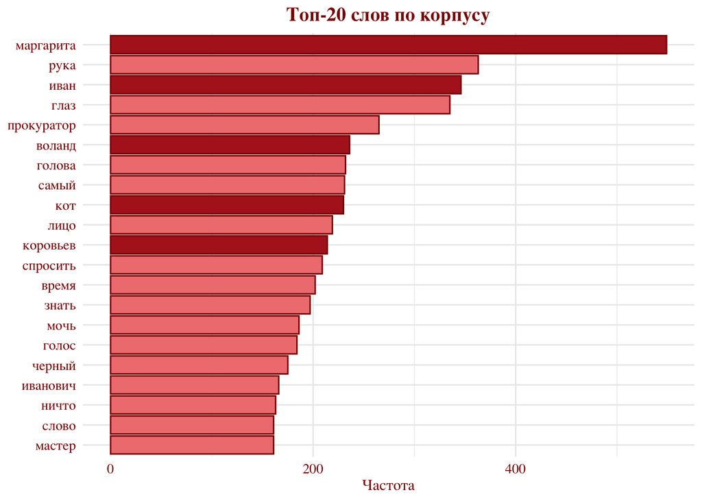

```r
# список персонажей для выделения
characters <- c("маргарита", "воланд", "иван", "азазелло",
                "коровьев", "кот", "пилат", "левий")

frequencies_1 |>
  slice_max(n, n = 20) |>
  mutate(type = ifelse(lemma %in% characters, "персонаж", "другое")) |>
  ggplot(aes(x = fct_reorder(lemma, n), y = n, fill = type)) +
  geom_col(color = "darkred", show.legend = FALSE) +
  coord_flip() +
  scale_fill_manual(values = c("персонаж" = "firebrick", "другое" = "lightcoral")) +
  labs(x = NULL, y = "Частота", title = "Топ-20 слов по корпусу") +
  theme_minimal(base_family = "serif") +
  theme(
    plot.title = element_text(size = 14, face = "bold", hjust = 0.5, color = "darkred"),
    axis.text = element_text(size = 10, color = "darkred"),
    axis.title = element_text(size = 11, color = "darkred")
  )
```

Анализ показал преобладание лемм, связанных с именами персонажей (маргарита, иван, воланд, кот) и частями тел (рука, глаз, голова, лицо). Это говорит нам о том, что в тексте концентрируется внимание на героях, описании их мимики и жестов, что отражает жанр текста - роман. Маргарита, Иван, Воланд, Коровьев, Кот - это имена, которые встречаются наиболее часто, потому что они значимы для повествования.

Частота по главам:

```r
frequencies_2 <- token_words |> count(chapter_number, chapter_name, lemma, sort = TRUE)

frequencies_2 |>
  group_by(chapter_number, chapter_name) |>
  slice_max(n, n = 1) |>
  ungroup()
```

| chapter_number | chapter_name | lemma | n |
| --- | --- | --- | --- |
| 1 | Никогда не разговаривайте с неизвестными | берлиоз | 49 |
| 2 | Понтий Пилат | прокуратор | 96 |
| 3 | Седьмое доказательство | берлиоз | 25 |
| 4 | Погоня | иван | 51 |
| 5 | Было дело в Грибоедове | иван | 18 |
| 6 | Шизофрения, как и было сказано | иван | 38 |
| 7 | Нехорошая квартирка | степ | 48 |
| 8 | Поединок между профессором и поэтом | иван | 71 |
| 9 | Коровьевские штуки | иванович | 63 |
| 9 | Коровьевские штуки | никанор | 63 |

[output cut: 24 more lines]

Визуализация топ-1 слова в каждой главе

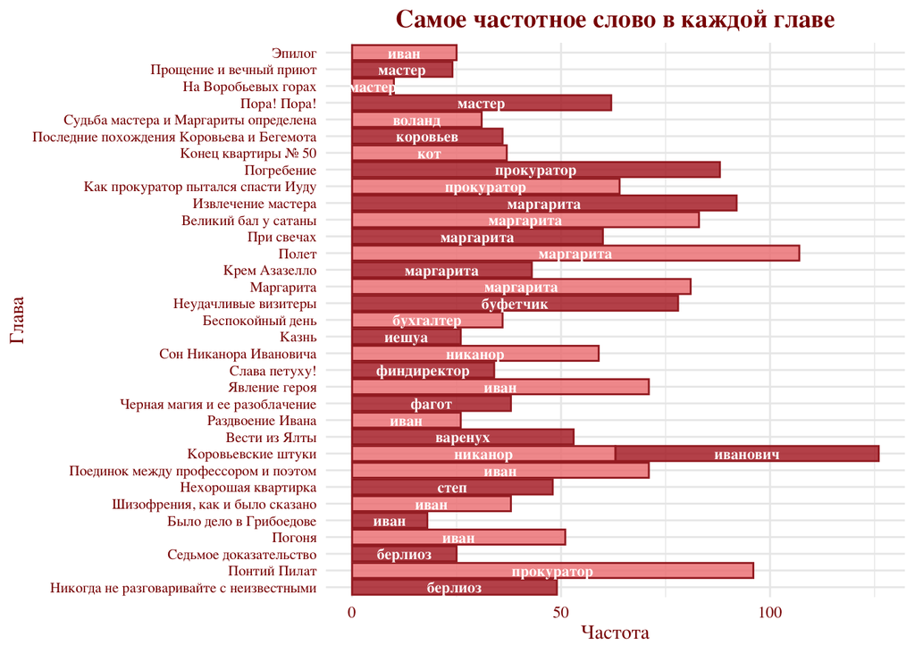

```r
frequencies_2 |>
  group_by(chapter_number, chapter_name) |>
  slice_max(n, n = 1) |>
  ungroup() |>
  mutate(row_color = if_else(row_number() %% 2 == 0, "lightcoral", "firebrick")) |>
  ggplot(aes(x = reorder(chapter_name, chapter_number), y = n, fill = row_color)) +
  geom_col(color = "brown", alpha = 0.8, show.legend = FALSE) +
  geom_text(aes(label = lemma),
            position = position_stack(vjust = 0.5),
            size = 3,
            color = "white",
            fontface = "bold") +
  scale_fill_identity() +
  coord_flip() +
  labs(x = "Глава", y = "Частота",
       title = "Самое частотное слово в каждой главе") +
  theme_minimal(base_family = "serif") +
  theme(
    plot.title = element_text(size = 14, face = "bold", hjust = 0.5, color = "darkred"),
    axis.text = element_text(size = 9, color = "darkred"),
    axis.title = element_text(size = 11, color = "darkred"),
    axis.text.y = element_text(size = 8)
  )
```

На графике видно, что в разных главах лидируют разные персонажи или ключевые понятия, соответствующие основной сцене. Например, главы с московскими событиями характеризуются доминированием слов вроде «иван», «берлиоз», «воланд», тогда как в главах библейского цикла ключевым словом становится «прокуратор» или «иешуа».

## Регулярные выражения

Подсчет частоты упоминания **всех персонажей** по главам + нормированная частота на 1000 слов текста

```r
persons <- c(
  "воланд[ауом]?|мессир(у|ом)?|профессор(у|ом|а)?",
  "маргарит[аыуойе]|ма[р]+гарит[аыуойе]",
  "мастер[ау]?",
  "иван[ауом]?|бездомн(ый|ого|ому|ым)?|понырев[ау]?",
  "азазелл[оау]",
  "коровь[её]в[ау]?|фагот(у|ом|а)?",
  "бегемот[ауом]?|кот[ауом]?",
  "пилат[ауом]?|понтий|прокуратор[ауом]?",
  "иешуа|га-ноцри",
  "левий|матвей",
  "берлиоз[ауом]?|михаил[ауом]?|александрович[ауом]?",
  "латунск[а-я]+",
  "алоизий|могарыч"
)

regex <- paste0("\\b(", paste(persons, collapse="|"), ")\\b")

persons_ <- data |>
  mutate(text_norm = stringr::str_to_lower(stringr::str_replace_all(text, "ё","е")),
         hits = stringr::str_count(text_norm, regex), # частота упоминаний
         words_total = str_count(text_norm, "\\S+"),
         hits_norm = hits / words_total * 1000) # частота упоминаний на 1000 слов текста

persons_ |>
  select(part, chapter_number, chapter_name, hits, hits_norm) |>
  arrange(desc(hits))
```

| part | chapter_number | chapter_name | hits | hits_norm |
| --- | --- | --- | --- | --- |
| вторая | 24 | Извлечение мастера | 389 | 54.4817927 |
| первая | 2 | Понтий Пилат | 219 | 31.0066544 |
| вторая | 22 | При свечах | 212 | 51.9990189 |
| вторая | 23 | Великий бал у сатаны | 192 | 41.8756816 |
| вторая | 26 | Погребение | 160 | 24.0456868 |
| вторая | 30 | Пора! Пора! | 160 | 42.7122264 |
| вторая | 19 | Маргарита | 128 | 33.2294912 |
| вторая | 21 | Полет | 117 | 28.6483839 |
| первая | 13 | Явление героя | 109 | 17.1141466 |
| первая | 1 | Никогда не разговаривайте с неизвестными | 108 | 29.8260149 |

[output cut: 23 more lines]

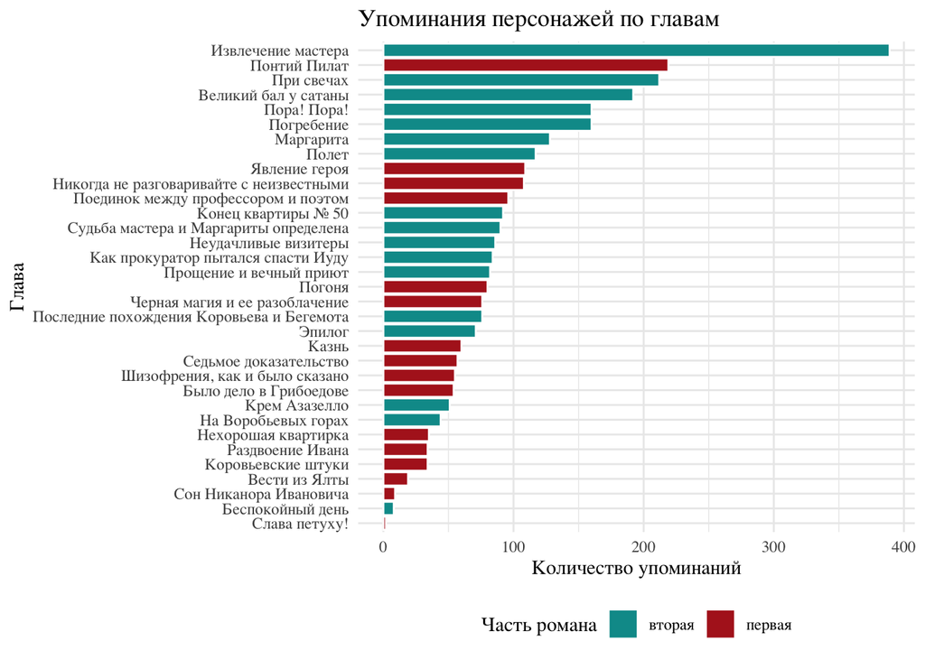

```r
ggplot(persons_, aes(x = fct_reorder(chapter_name, hits), y = hits, fill = part)) +
  geom_col(color = "white") +
  coord_flip() +
  scale_fill_manual(values = c("первая" = "firebrick", "вторая" = "#009999")) +
  theme_minimal(base_family = "serif") +
  labs(x = "Глава", y = "Количество упоминаний",
       title = "Упоминания персонажей по главам",
       fill = "Часть романа") +
  theme(legend.position = "bottom")
```

Наибольшее количество упоминаний приходится на главы с активным развитием сюжета (24, 2, 22, 23) и множеством диалогов — именно в них повествование сосредоточено на взаимодействии героев. Можно заметить, что в 20х главах происходит наибольшее количество взаимодействий персонажей, что говорит нам о кульминации событий романа — моментом, когда в повествовании одновременно присутствует несколько ключевых персонажей и развивается линия Маргариты.

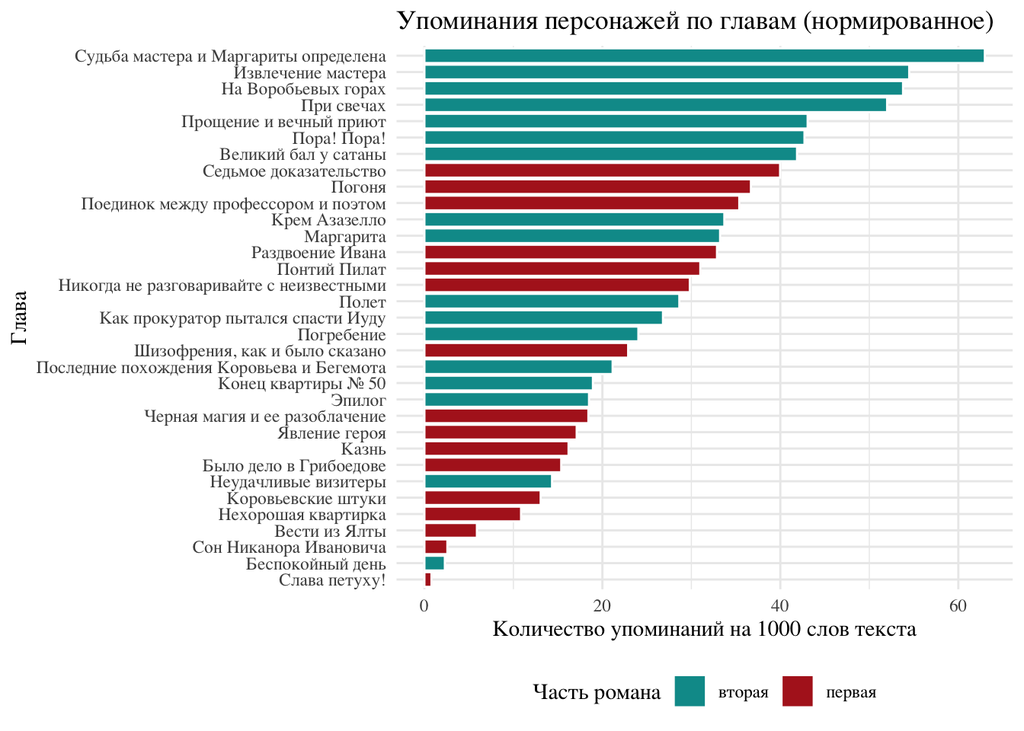

```r
ggplot(persons_, aes(x = fct_reorder(chapter_name, hits_norm), y = hits_norm, fill = part)) +
  geom_col(color = "white") +
  coord_flip() +
  scale_fill_manual(values = c("первая" = "firebrick", "вторая" = "#009999")) +
  theme_minimal(base_family = "serif") +
  labs(x = "Глава", y = "Количество упоминаний на 1000 слов текста",
       title = "Упоминания персонажей по главам (нормированное)",
       fill = "Часть романа") +
  theme(legend.position = "bottom")
```

## Log-likelihood / log-ratio

```r
# Создаем корпус и документ-термин матрицу
corp <- corpus(data, text_field = "text")
toks <- tokens(corp, remove_punct = TRUE) |>
  tokens_tolower() |>
  tokens_replace(pattern = "ё", replacement = "е") |>
  tokens_keep(pattern = "^[а-я-]+$", valuetype = "regex") |>
  tokens_remove(stop_list)

dfm_all <- dfm(toks)

# Добавляем метаданные о частях романа
docvars(dfm_all, "part") <- data$part

# Log-likelihood анализ
key_ll <- textstat_keyness(dfm_all,
                          target = docvars(dfm_all, "part") == "первая",
                          measure = "chi2")
head(key_ll, 15)
```

|  | feature | chi2 | p | n_target | n_reference |
| --- | --- | --- | --- | --- | --- |
| 1 | иван | 172.61373 | 0.000000e+00 | 210 | 31 |
| 2 | никанор | 90.23782 | 0.000000e+00 | 84 | 4 |
| 3 | варенуха | 65.21742 | 6.661338e-16 | 72 | 8 |
| 4 | берлиоз | 64.31848 | 1.110223e-15 | 67 | 6 |
| 5 | степа | 57.36809 | 3.619327e-14 | 59 | 5 |
| 6 | ивана | 55.99376 | 7.271961e-14 | 60 | 6 |
| 7 | римский | 50.10549 | 1.456946e-12 | 63 | 10 |
| 8 | поэт | 45.60251 | 1.448563e-11 | 40 | 1 |
| 9 | иешуа | 43.01193 | 5.440715e-11 | 51 | 7 |
| 10 | иванович | 38.58441 | 5.243616e-10 | 82 | 28 |

[output cut: 5 more lines]

[figure not shown]

```r
# Визуализация Log-likelihood (топ-15 слов для каждой части)
key_ll_top <- bind_rows(
  key_ll |> filter(chi2 > 0) |> slice_max(chi2, n = 15),  # слова для первой части
  key_ll |> filter(chi2 < 0) |> slice_min(chi2, n = 15)   # слова для второй части
) |>
  mutate(type = ifelse(chi2 > 0, "первая часть", "вторая часть"))

ggplot(key_ll_top, aes(x = fct_reorder(feature, chi2), y = chi2, fill = type)) +
  geom_col(show.legend = TRUE) +
  coord_flip() +
  scale_fill_manual(values = c("первая часть" = "firebrick", "вторая часть" = "#009999")) +
  labs(x = NULL, y = "Log-likelihood (chi2)",
       title = "Ключевые слова по частям романа (Log-likelihood)",
       fill = "Часть романа") +
  theme_minimal(base_family = "serif") +
  theme(legend.position = "bottom")
```

```r
# Log-ratio анализ - получаем результаты для обеих частей
key_lr <- textstat_keyness(dfm_all,
                          target = docvars(dfm_all, "part") == "первая",
                          measure = "lr")
head(key_lr, 20)
```

|  | feature | G2 | p | n_target | n_reference |
| --- | --- | --- | --- | --- | --- |
| 1 | иван | 187.25236 | 0.000000e+00 | 210 | 31 |
| 2 | никанор | 106.14952 | 0.000000e+00 | 84 | 4 |
| 3 | берлиоз | 72.49289 | 0.000000e+00 | 67 | 6 |
| 4 | варенуха | 72.32602 | 0.000000e+00 | 72 | 8 |
| 5 | степа | 64.92167 | 7.771561e-16 | 59 | 5 |
| 6 | ивана | 62.59519 | 2.553513e-15 | 60 | 6 |
| 7 | поэт | 55.52920 | 9.203749e-14 | 40 | 1 |
| 8 | римский | 54.06117 | 1.942890e-13 | 63 | 10 |
| 9 | арестант | 47.79497 | 4.731993e-12 | 30 | 0 |
| 10 | иешуа | 46.93293 | 7.345791e-12 | 51 | 7 |

[output cut: 10 more lines]

[figure not shown]

```r
# Визуализация Log-ratio (топ-15 слов для каждой части)
key_lr_top <- bind_rows(
  key_lr |> filter(G2 > 0) |> slice_max(G2, n = 15),  # слова для первой части
  key_lr |> filter(G2 < 0) |> slice_min(G2, n = 15)   # слова для второй части
) |>
  mutate(type = ifelse(G2 > 0, "первая часть", "вторая часть"))

ggplot(key_lr_top, aes(x = fct_reorder(feature, G2), y = G2, fill = type)) +
  geom_col(show.legend = TRUE) +
  coord_flip() +
  scale_fill_manual(values = c("первая часть" = "firebrick", "вторая часть" = "#009999")) +
  labs(x = NULL, y = "Log-ratio (G2)",
       title = "Ключевые слова по частям романа (Log-ratio)",
       fill = "Часть романа") +
  theme_minimal(base_family = "serif") +
  theme(legend.position = "bottom")
```

В первой части романа стастистически значимо чаще встречаются имена Иван, Никанор, Веренуха, которые являются персонажами Московской сюжетной линии. Во второй части романа чаще встречаются имена Маргарита, Азазелло, Воланд, которые являются персанажами мистической сюжетной линии.

## Семантическая сеть

```r
bigrams <- data |>
  mutate(text = str_replace_all(text, "ё", "е")) |>
  unnest_tokens(bigram, text, token = "ngrams", n = 2) |>
  separate(bigram, c("w1", "w2"), sep = " ") |>
  filter(
    str_detect(w1, "^[а-я-]+$"),
    str_detect(w2, "^[а-я-]+$"),
    !w1 %in% stop_list,
    !w2 %in% stop_list
  )

edges <- bigrams |>
  count(w1, w2, sort = TRUE) |>
  filter(n >= 5)

# функция для тестирования порогов
test_thresholds <- function() {
  thresholds <- c(2, 5, 8, 10, 15, 20, 25)

  for(thresh in thresholds) {
    edges_test <- edges |> filter(n >= thresh)

    cat(sprintf("Порог %2d: %4d связей, %3d уникальных слов | ",
                thresh, nrow(edges_test),
                n_distinct(c(edges_test$w1, edges_test$w2))))

    if(nrow(edges_test) > 0) {
      g_test <- graph_from_data_frame(edges_test, directed = FALSE)
      cat(sprintf("Плотность: %.4f", edge_density(g_test)))
    }
    cat("\n")
  }
}

test_thresholds()
```

```
## Порог  2:  145 связей, 231 уникальных слов | Плотность: 0.0055
## Порог  5:  145 связей, 231 уникальных слов | Плотность: 0.0055
## Порог  8:   61 связей,  96 уникальных слов | Плотность: 0.0134
## Порог 10:   42 связей,  65 уникальных слов | Плотность: 0.0202
## Порог 15:   23 связей,  42 уникальных слов | Плотность: 0.0267
## Порог 20:   10 связей,  18 уникальных слов | Плотность: 0.0654
## Порог 25:    5 связей,  10 уникальных слов | Плотность: 0.1111
```

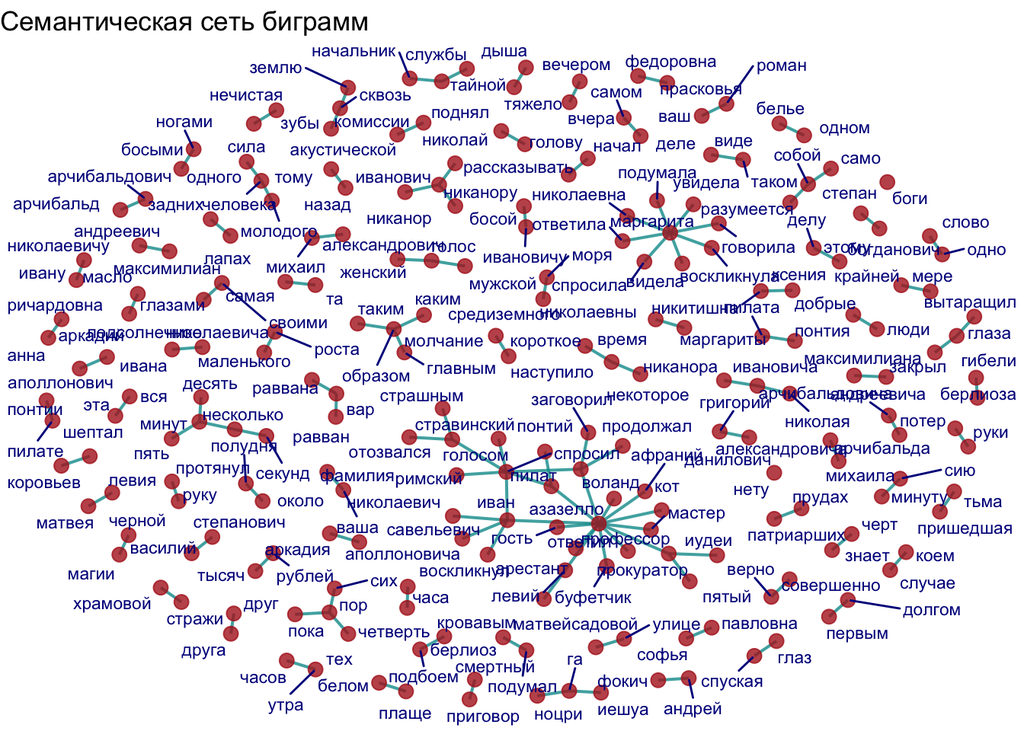

```r
# граф
g <- graph_from_data_frame(edges, directed = FALSE)
set.seed(30)
ggraph(g, layout = "fr") +
  geom_edge_link(alpha = .8, color = "#009999", width = 0.7) +
  geom_node_point(color = "firebrick", size = 3, alpha = 0.8) +
  geom_node_text(aes(label = name), repel = TRUE, size = 3, color = "darkblue") +
  labs(title = "Семантическая сеть биграмм") +
  theme_void()
```

## Тематическое моделирование (LDA)

Подготовка данных и построение модели LDA

```r
dtm_tbl <- token_words |>
  filter(!is.na(lemma)) |>
  count(document = as.character(chapter_number), term = lemma, sort = TRUE)

# преобразуем в объект типа Document-Term-Matrix
dtm <- dtm_tbl |>
  cast_dtm(document, term, n)

# параметры LDA
k <- 10
seed <- 1234
control <- list(seed = seed)

# Обучаем модель
lda_model <- LDA(dtm, k = k, method = "Gibbs", control = control)
```

Топ-термы по темам (beta)

```r
topics_beta <- tidy(lda_model, matrix = "beta")

top_n <- 10
top_terms <- topics_beta |>
  group_by(topic) |>
  slice_max(beta, n = top_n) |>
  ungroup() |>
  arrange(topic, -beta)

top_terms |>
  group_by(topic) |>
  summarize(terms = paste(term, collapse = ", ")) |>
  ungroup()
```

| topic | terms |
| --- | --- |
| 1 | коровьев, бегемот, дом, арчибальд, арчибальдович, веранда, грибоедов, швейцар, гражданк, ресторан |
| 2 | римский, варенух, финдиректор, кабинет, степ, варьет, кот, администратор, трубка, квартира |
| 3 | берлиоз, буфетчик, профессор, иностранец, поплавский, бездомный, москва, андреевич, максимилиан, подумать |
| 4 | иванович, никанор, гражданин, председатель, фагот, артист, коровьев, сцена, кот, зал, квартира |
| 5 | глаз, рука, голова, самый, спросить, лицо, мочь, знать, голос, черный |
| 6 | иван, николаевич, поэт, гость, рюхин, стравинский, роман, рассказ, переулок, идти |
| 7 | дорога, левий, столб, иешуа, вода, казнь, холм, город, цепь, солнце, гора |
| 8 | маргарита, воланд, мастер, азазелло, коровьев, кот, мессир, маргарит, бегемот, ничто |
| 9 | прокуратор, пилат, сад, город, арестант, иуд, гость, афраний, секретарь, пилата |
| 10 | маргарита, николаевна, луна, наташа, николай, река, окно, рядом, воздух, щетка, латунский |

Визуализация: топ-термы по темам (гистограммы)

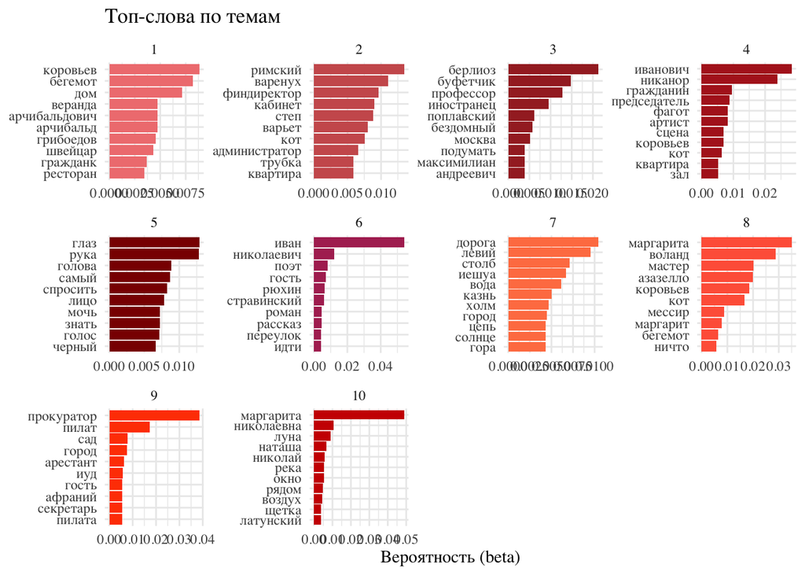

```r
red_palette <- c("lightcoral", "indianred", "brown", "firebrick", "darkred",
                 "maroon", "coral", "tomato", "orangered", "red3")
top_terms |>
  mutate(term = reorder_within(term, beta, topic)) |>
  ggplot(aes(x = term, y = beta, fill = factor(topic))) +
  geom_col(show.legend = FALSE) +
  facet_wrap(~ topic, scales = "free") +
  coord_flip() +
  scale_x_reordered() +
  scale_fill_manual(values = red_palette) +
  labs(title = "Топ-слова по темам",
       x = NULL, y = "Вероятность (beta)") +
  theme_minimal(base_family = "serif")
```

На основе топ-слов, представленных в гистограммах, Можно выделить 10 тем: 1. Свита Воланда и комические сцены 2. Бюрократическая и городская среда 3. Московская завязка, персонажи начальных эпизодов 4. Театр, сцена и публичные выступления 5. Описательная лексика 6. Иван Бездомный и московская линия 7. Библейская линия 8. Маргарита и центральные мистические эпизоды 9. Сюжетная ветвь Понтия Пилата 10. Маргарита и ночные мотивы

Распределение тем по главам

```r
topics_gamma <- tidy(lda_model, matrix = "gamma") |>
  group_by(document) |>
  slice_max(gamma, n = 1) |>
  ungroup() |>
  mutate(document = as.numeric(document))

# Добавляем информацию о главах
chapters_info <- data |>
  select(chapter_number, chapter_name, part) |>
  distinct() |>
  mutate(document = as.character(chapter_number))

topics_with_chapters <- topics_gamma |>
  left_join(chapters_info, by = c("document" = "chapter_number"))

topics_with_chapters |> select(part, document, chapter_name, topic, gamma)
```

| part | document | chapter_name | topic | gamma |
| --- | --- | --- | --- | --- |
| первая | 1 | Никогда не разговаривайте с неизвестными | 3 | 0.4099949 |
| первая | 10 | Вести из Ялты | 2 | 0.4818821 |
| первая | 11 | Раздвоение Ивана | 5 | 0.3724884 |
| первая | 12 | Черная магия и ее разоблачение | 4 | 0.4287994 |
| первая | 13 | Явление героя | 5 | 0.5112620 |
| первая | 14 | Слава петуху! | 2 | 0.4036223 |
| первая | 15 | Сон Никанора Ивановича | 4 | 0.5174129 |
| первая | 16 | Казнь | 7 | 0.6098553 |
| вторая | 17 | Беспокойный день | 2 | 0.4941973 |
| вторая | 18 | Неудачливые визитеры | 3 | 0.4314809 |

[output cut: 23 more lines]

Визуализация доминирующих тем по главам

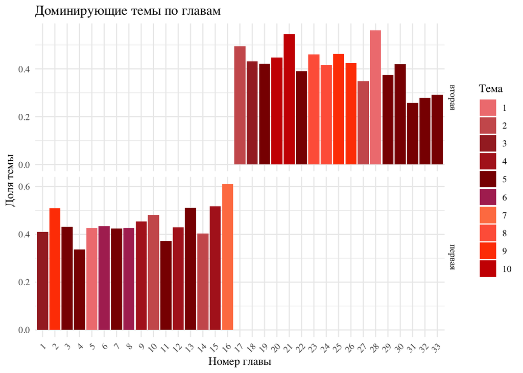

```r
ggplot(topics_with_chapters, aes(x = factor(document), y = gamma, fill = factor(topic))) +
  geom_col() +
  facet_grid(part ~ ., scales = "free", space = "free") +
  scale_fill_manual(values = red_palette, name = "Тема") +
  labs(title = "Доминирующие темы по главам",
       x = "Номер главы", y = "Доля темы", fill = "Тема") +
  theme_minimal(base_family = "serif") +
  theme(axis.text.x = element_text(angle = 45, hjust = 1))
```

**Интерпретация тем на основе топ-слов и принадлежности к главам**

```r
topics_interpretation <- top_terms |>
  group_by(topic) |>
  summarise(
    top_words = paste(head(term, 10), collapse = ", "),  # топ-10 слов для каждой темы
    .groups = "drop"
  )

# Примеры глав для каждой темы
example_chapters <- topics_with_chapters |>
  group_by(topic) |>
  slice_max(gamma, n = 3) |>
  select(topic, chapter_number = document, chapter_name, gamma) |>
  arrange(topic, desc(gamma))

# Все данные
interpretation_summary <- example_chapters |>
  left_join(topics_interpretation, by = "topic") |>
  select(topic, top_words, chapter_number, chapter_name, gamma) |>
  arrange(topic, desc(gamma))

interpretation_summary
```

| topic | top_words | chapter_number | chapter_name | gamma |
| --- | --- | --- | --- | --- |
| 1 | коровьев, бегемот, дом, арчибальд, арчибальдович, веранда, грибоедов, швейцар, гражданк, ресторан | 28 | Последние похождения Коровьева и Бегемота | 0.5621219 |
| 1 | коровьев, бегемот, дом, арчибальд, арчибальдович, веранда, грибоедов, швейцар, гражданк, ресторан | 5 | Было дело в Грибоедове | 0.4253589 |
| 2 | римский, варенух, финдиректор, кабинет, степ, варьет, кот, администратор, трубка, квартира | 17 | Беспокойный день | 0.4941973 |
| 2 | римский, варенух, финдиректор, кабинет, степ, варьет, кот, администратор, трубка, квартира | 10 | Вести из Ялты | 0.4818821 |
| 2 | римский, варенух, финдиректор, кабинет, степ, варьет, кот, администратор, трубка, квартира | 14 | Слава петуху! | 0.4036223 |
| 3 | берлиоз, буфетчик, профессор, иностранец, поплавский, бездомный, москва, андреевич, максимилиан, подумать | 18 | Неудачливые визитеры | 0.4314809 |
| 3 | берлиоз, буфетчик, профессор, иностранец, поплавский, бездомный, москва, андреевич, максимилиан, подумать | 1 | Никогда не разговаривайте с неизвестными | 0.4099949 |
| 4 | иванович, никанор, гражданин, председатель, фагот, артист, коровьев, сцена, кот, зал | 15 | Сон Никанора Ивановича | 0.5174129 |
| 4 | иванович, никанор, гражданин, председатель, фагот, артист, коровьев, сцена, кот, зал | 9 | Коровьевские штуки | 0.4541314 |
| 4 | иванович, никанор, гражданин, председатель, фагот, артист, коровьев, сцена, кот, зал | 12 | Черная магия и ее разоблачение | 0.4287994 |

[output cut: 13 more lines]

Результаты LDA показывают, что в тексте выделяется несколько устойчивых тематических кластеров, каждый из которых соответствует определённым сюжетным линиям романа. Моделирование подтверждает структуру романа (Московская линия, мистическая линия, библейская линия), в которой темы отражают композиционные блоки и смену повествовательных миров.